# 2. házi feladat

#Előkészületek

```r
library(data.table)
library(ggplot2)
library(scales)
crime <- fread("C:/Users/barat_ojs0p6a/Documents/eltecon-ds-class/data/crime.csv")
```

#1. az adattáblában keressétek meg, hogy melyik az 5 leggyakoribb “OFFENSE_CODE_GROUP”, csak azokra a sorokra leszűrve, ahol a “SHOOTING” értéke “Y”.

```r
topFiveOffense <- crime[SHOOTING == "Y", .N, by = OFFENSE_CODE_GROUP] [order(-N)][1:5][[1]]
topFiveOffense
```

```
## [1] "Aggravated Assault" "Homicide"           "Warrant Arrests"
## [4] "Firearm Violations" "Ballistics"
```

#2. az eredeti adattáblát szűrjétek le azokra a sorokra, ahol a “SHOOTING” értéke “Y”, ÉS az “OFFENSE_CODE_GROUP” oszlop értéke az 1.-es pontban kiszámolt 5 leggyakoribb valamelyike.

```r
crimeTopFive <- crime[SHOOTING == "Y" & OFFENSE_CODE_GROUP %in% topFiveOffense]
crimeTopFive
```

```
##      INCIDENT_NUMBER OFFENSE_CODE OFFENSE_CODE_GROUP
##   1:      I182069509          413 Aggravated Assault
##   2:      I182068876          413 Aggravated Assault
##   3:      I182067317          111           Homicide
##   4:      I182067317         2662         Ballistics
##   5:      I182066420          413 Aggravated Assault
##  ---
## 826:      I152051161          413 Aggravated Assault
## 827:      I152051161         1503 Firearm Violations
## 828:      I152051161         3125    Warrant Arrests
## 829:      I152050961          413 Aggravated Assault
## 830:      I152050036          413 Aggravated Assault
##                              OFFENSE_DESCRIPTION DISTRICT REPORTING_AREA
##   1:              ASSAULT - AGGRAVATED - BATTERY      E18            540
##   2:              ASSAULT - AGGRAVATED - BATTERY       B2            183
```

[output cut: 33 more lines]

#3. Vizualizáljátok ezen bűnesetek gyakoriságát, órák szerint, és valamilyen módon (szín, facet, stb.) elkülönítve egymástól az 5 “OFFENSE_CODE_GROUP”-ot.

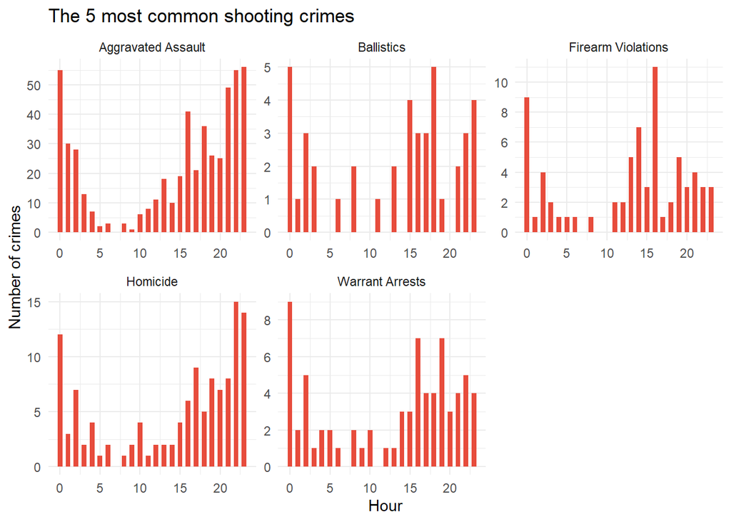

```r
crimeToPlot <- crimeTopFive[, .N, by = c("HOUR", "OFFENSE_CODE_GROUP")]

ggplot(crimeToPlot, aes(x = HOUR, y = N)) +
    geom_col(width = 0.6, fill = rgb(231, 76, 60, max = 255)) +
    facet_wrap((~OFFENSE_CODE_GROUP), scales = "free") +
    viridis::scale_fill_viridis(discrete = TRUE) +
    theme_minimal() +
    ylab("Number of crimes") +
    scale_y_continuous(breaks = pretty_breaks()) +
    xlab("Hour") +
    labs(title = "The 5 most common shooting crimes")
```

#A markdown fájlban a kód mellett írjatok pár szót arról is, hogy milyen mintázatot fedeztek fel az adatban, és annak milyen lehetséges magyarázata van.

#A súlyos testi sértések száma aránylag a legamasabb az összes közül.

#A súlyos testi sértés és a gyilkosság azért mutathat nagyon hasonló trendet, mert az utóbbi az előbbi egy súlyosabb változata.